# Which fire-years to validate

Step 10 · whole-country burned area per fire-year · collection-01

Published

August 21, 2026

Three fire-years have to be chosen for the validation campaign (`docs/10-validation.md` §8). This notebook supplies the fire-regime half of that decision: **whole-country burned area per fire-year**, from every independent burned-area product available, so a year can be placed as low / moderate / extreme before it is committed to.

Our own 30 m product is **not** in this pass. Measuring it costs ~210 s per fire-year (its `burned_monthly` band has a MODE pyramid, so the area has to be read at native resolution — see the script’s docstring), and the independent products are the right basis for the choice anyway: picking validation years by our own map’s extremes would let the product select the years it is judged on. The series is added by flipping `SHOWN` in the next chunk once it exists.

Everything here is **fire-year** — 1 May Y → 30 Apr Y+1, named by the start year. Never a calendar year. The table comes from `collection-01/scripts/10_burned_area_by_fire_year.py`.

```r
knitr::opts_chunk$set(message = FALSE, warning = FALSE, dev = "png", dpi = 120)
knitr::opts_knit$set(root.dir = normalizePath(if (dir.exists("collection-01")) "." else "../.."))
library(data.table)
library(ggplot2)
```

```r
CSV <- "collection-01/validation/burned_area_by_fire_year.csv"
stopifnot(file.exists(CSV))

# Which products to show. Our own 30 m series is NOT here: it costs ~210 s per fire-year
# to measure, so it is computed separately. Add "ours" to SHOWN (and it becomes the
# natural REF) once collection-01/validation/ holds its full FY1999-2024 series.
SHOWN <- c("mcd64", "vnp64", "firecci")
REF   <- "mcd64"          # the reference series: the only one spanning the whole record

LABEL <- c(ours = "MapBiomas ARG col-1 (30 m)", mcd64 = "MCD64A1 (MODIS, 463 m)",
           vnp64 = "VNP64A1 (VIIRS, 463 m)",    firecci = "FireCCI51 (250 m)")

ba <- fread(CSV)[product %in% SHOWN]
ba[, mha := area_ha / 1e6]
ba[, partial := as.logical(partial)]
ba[, product := factor(product, levels = intersect(names(LABEL), SHOWN),
                       labels = LABEL[intersect(names(LABEL), SHOWN)])]
setorder(ba, product, fire_year)
ba[, .(years = .N, full = sum(!partial), from = min(fire_year), to = max(fire_year)),
   by = product]
```

```
                  product years  full  from    to
                   <fctr> <int> <int> <int> <int>
1: MCD64A1 (MODIS, 463 m)    26    25  2000  2025
2: VNP64A1 (VIIRS, 463 m)    15    14  2011  2025
3:      FireCCI51 (250 m)    20    19  2001  2020
```

A **partial** year is one whose 1 May → 30 Apr window is only half-covered by that product’s archive. Its area is an undercount and must never be read as a quiet fire year, so partial points are drawn hollow below and excluded from every statistic.

## Burned area per fire-year, all products

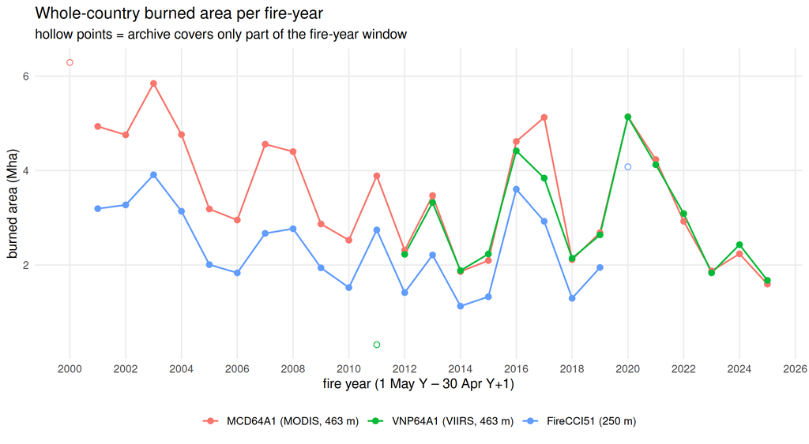

```r
full <- ba[!is.na(mha)]
ggplot(full, aes(fire_year, mha, colour = product)) +
  geom_line(data = full[!(partial)], linewidth = 0.7) +
  geom_point(aes(shape = partial), size = 2.1, fill = "white") +
  scale_shape_manual(values = c(`FALSE` = 19, `TRUE` = 21), guide = "none") +
  scale_x_continuous(breaks = seq(1998, 2026, 2)) +
  labs(x = "fire year (1 May Y – 30 Apr Y+1)", y = "burned area (Mha)",
       colour = NULL,
       title = "Whole-country burned area per fire-year",
       subtitle = "hollow points = archive covers only part of the fire-year window") +
  theme_minimal(base_size = 12) +
  theme(legend.position = "bottom", panel.grid.minor = element_blank())
```

The products disagree in level — coarse sensors miss small fires and over-call at scar edges, and our 30 m map resolves scars they cannot see — so the useful signal here is **the shape**: which years stand out, and whether they stand out in every product or only one. A year that is extreme in all of them is an extreme year; a year extreme in one is a disagreement worth understanding before validating it.

## Ranked by the reference series

`MCD64A1` is the reference for ranking because it is the **only product covering the whole record** — VNP64A1 starts at FY2012 and FireCCI51 ends at FY2019, so neither can rank a year against the full series. Terciles of the MCD64A1 series define low / moderate / extreme.

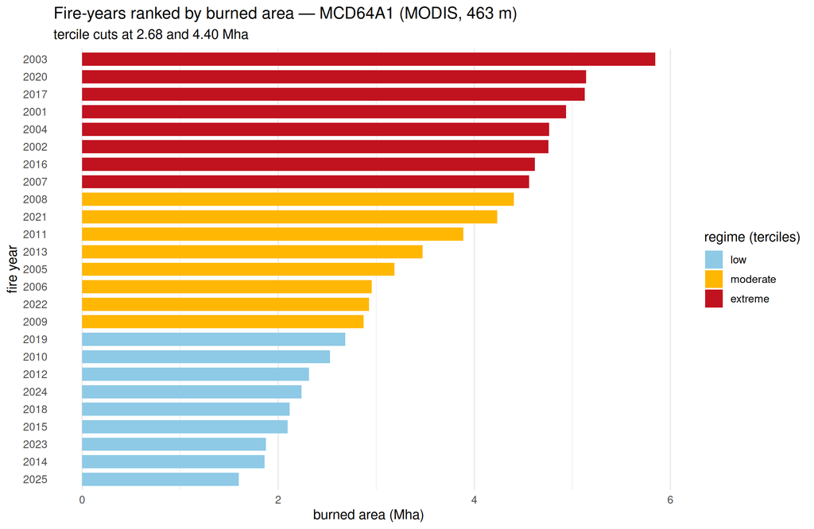

```r
ref <- ba[product == LABEL[REF] & !(partial) & !is.na(mha)]
qs  <- quantile(ref$mha, c(1/3, 2/3))
ref[, regime := factor(fifelse(mha <= qs[1], "low",
                        fifelse(mha <= qs[2], "moderate", "extreme")),
                       levels = c("low", "moderate", "extreme"))]

ggplot(ref, aes(reorder(factor(fire_year), mha), mha, fill = regime)) +
  geom_col(width = 0.75) +
  coord_flip() +
  scale_fill_manual(values = c(low = "#8ecae6", moderate = "#ffb703", extreme = "#c1121f")) +
  labs(x = "fire year", y = "burned area (Mha)", fill = "regime (terciles)",
       title = paste0("Fire-years ranked by burned area — ", LABEL[REF]),
       subtitle = sprintf("tercile cuts at %.2f and %.2f Mha", qs[1], qs[2])) +
  theme_minimal(base_size = 12) +
  theme(panel.grid.major.y = element_blank())
```

## Do the products agree on which years stand out?

A year that is extreme in every product is an extreme year. A year extreme in only one is a disagreement to understand *before* committing interpretation effort to it. Each series is standardised to its own mean and SD over the years it covers, so the comparison is of shape, not level.

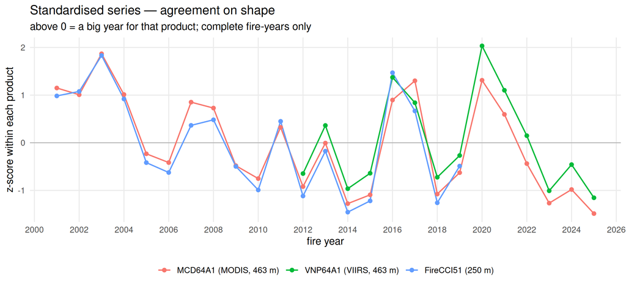

```r
z <- ba[!(partial) & !is.na(mha)][, .(fire_year, product, z = (mha - mean(mha)) / sd(mha)),
                                 by = product][, -1]
ggplot(z, aes(fire_year, z, colour = product)) +
  geom_hline(yintercept = 0, linewidth = 0.3, colour = "grey60") +
  geom_line(linewidth = 0.7) + geom_point(size = 1.8) +
  scale_x_continuous(breaks = seq(1998, 2026, 2)) +
  labs(x = "fire year", y = "z-score within each product", colour = NULL,
       title = "Standardised series — agreement on shape",
       subtitle = "above 0 = a big year for that product; complete fire-years only") +
  theme_minimal(base_size = 12) +
  theme(legend.position = "bottom", panel.grid.minor = element_blank())
```

## The decision table

Fire regime is only one of the three constraints in `docs/10` §8. The other two are the **Landsat sensor era** the year sits in, and **how many independent burned-area products** exist to build the S2 omission-catcher stratum — a year with fewer gets a weaker S2 and a wider interval for the same interpretation effort (no bias, just less precision).

```r
era <- function(fy) fifelse(fy <= 2002, "L5 + L7 SLC-on",
                     fifelse(fy <= 2012, "L7 SLC-off (FY2012 = L7 only)",
                                         "L8 + L9"))
# Count of independent BURNED-AREA products (docs/10 §4.5): MCD64A1 from FY2001,
# FireCCI51 FY2001-2019, VNP64A1 FY2012 on. FIRMS active fire is present in every year
# and so is not counted -- it shifts no year relative to another.
n_aux <- function(fy) (fy >= 2001) + (fy >= 2001 & fy <= 2019) + (fy >= 2012)

dec <- ref[, .(fire_year, ref_mha = round(mha, 2), regime)]
dec[, `:=`(sensor_era = era(fire_year), aux_products = n_aux(fire_year))]
dec[, s2_strength := fifelse(aux_products >= 3, "strongest",
                      fifelse(aux_products == 2, "good", "weak"))]

# how many products call the year above their own mean -- a crude concordance count
zc <- dcast(z, fire_year ~ product, value.var = "z")
dec <- merge(dec, z[, .(n_products = .N, n_above = sum(z > 0)), by = fire_year],
             by = "fire_year", all.x = TRUE)
setorder(dec, -ref_mha)
knitr::kable(dec, align = "rrlllrrr", col.names = c(
  "fire year", paste0(REF, " (Mha)"), "regime", "sensor era", "S2 strength",
  "burned-area products", "products with data", "products above own mean"),
  caption = "Fire-years by burned area, with the constraints and the concordance count")
```

Fire-years by burned area, with the constraints and the concordance count

| fire year | mcd64 (Mha) | regime | sensor era | S2 strength | burned-area products | products with data | products above own mean |
| --- | --- | --- | --- | --- | --- | --- | --- |
| 2003 | 5.85 | extreme | L7 SLC-off (FY2012 = L7 only) | 2 | good | 2 | 2 |
| 2020 | 5.14 | extreme | L8 + L9 | 2 | good | 2 | 2 |
| 2017 | 5.13 | extreme | L8 + L9 | 3 | strongest | 3 | 3 |
| 2001 | 4.94 | extreme | L5 + L7 SLC-on | 2 | good | 2 | 2 |
| 2002 | 4.76 | extreme | L5 + L7 SLC-on | 2 | good | 2 | 2 |
| 2004 | 4.76 | extreme | L7 SLC-off (FY2012 = L7 only) | 2 | good | 2 | 2 |
| 2016 | 4.62 | extreme | L8 + L9 | 3 | strongest | 3 | 3 |
| 2007 | 4.56 | extreme | L7 SLC-off (FY2012 = L7 only) | 2 | good | 2 | 2 |
| 2008 | 4.40 | moderate | L7 SLC-off (FY2012 = L7 only) | 2 | good | 2 | 2 |
| 2021 | 4.23 | moderate | L8 + L9 | 2 | good | 2 | 2 |
| 2011 | 3.89 | moderate | L7 SLC-off (FY2012 = L7 only) | 2 | good | 2 | 2 |
| 2013 | 3.47 | moderate | L8 + L9 | 3 | strongest | 3 | 1 |
| 2005 | 3.19 | moderate | L7 SLC-off (FY2012 = L7 only) | 2 | good | 2 | 0 |
| 2006 | 2.95 | moderate | L7 SLC-off (FY2012 = L7 only) | 2 | good | 2 | 0 |
| 2022 | 2.93 | moderate | L8 + L9 | 2 | good | 2 | 1 |
| 2009 | 2.87 | moderate | L7 SLC-off (FY2012 = L7 only) | 2 | good | 2 | 0 |
| 2019 | 2.68 | low | L8 + L9 | 3 | strongest | 3 | 0 |
| 2010 | 2.53 | low | L7 SLC-off (FY2012 = L7 only) | 2 | good | 2 | 0 |
| 2012 | 2.31 | low | L7 SLC-off (FY2012 = L7 only) | 3 | strongest | 3 | 0 |
| 2024 | 2.24 | low | L8 + L9 | 2 | good | 2 | 0 |
| 2018 | 2.12 | low | L8 + L9 | 3 | strongest | 3 | 0 |
| 2015 | 2.10 | low | L8 + L9 | 3 | strongest | 3 | 0 |
| 2023 | 1.87 | low | L8 + L9 | 2 | good | 2 | 0 |
| 2014 | 1.86 | low | L8 + L9 | 3 | strongest | 3 | 0 |
| 2025 | 1.60 | low | L8 + L9 | 2 | good | 2 | 0 |

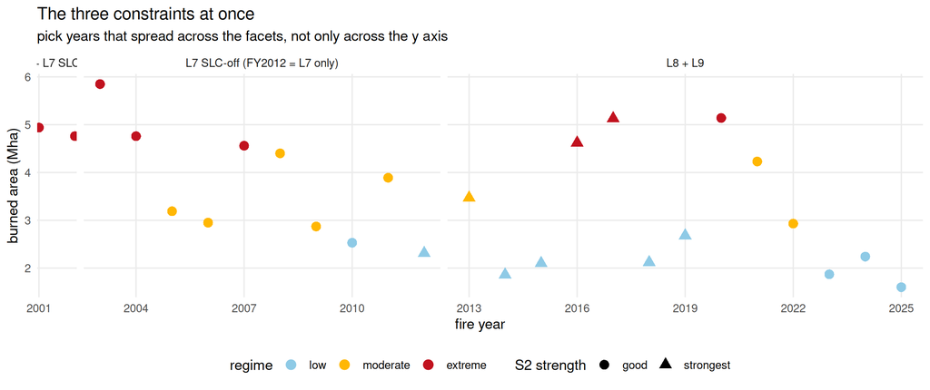

```r
ggplot(dec, aes(fire_year, ref_mha, colour = regime, shape = s2_strength)) +
  geom_point(size = 3.2) +
  scale_colour_manual(values = c(low = "#8ecae6", moderate = "#ffb703", extreme = "#c1121f")) +
  facet_grid(. ~ sensor_era, scales = "free_x", space = "free_x") +
  scale_x_continuous(breaks = seq(1998, 2026, 3)) +
  labs(x = "fire year", y = "burned area (Mha)", colour = "regime",
       shape = "S2 strength",
       title = "The three constraints at once",
       subtitle = "pick years that spread across the facets, not only across the y axis") +
  theme_minimal(base_size = 11) +
  theme(legend.position = "bottom", panel.grid.minor = element_blank())
```

### One trap in reading this table

The famous seasons are **not** where their calendar names put them. The Corrientes mega-fires of January–February 2022 fall in **FY2021** (1 May 2021 → 30 Apr 2022), which is why FY2021 reads 4.23 Mha while FY2022 is an unremarkable 2.93. The Delta del Paraná and Córdoba fires of August–October 2020 do land in FY2020, the second-largest year in the record. Any year picked by its reputation must be converted to a fire-year first.

Read the last figure as the actual choice: three years that sit in **different sensor-era facets** and at **different heights** characterise the collection far better than three years that happen to be convenient. Where a tie remains, prefer the year with the stronger S2 — it is free precision.